# Hemodynamic Response Functions

Bradley R. Buchsbaum

2026-10-03

## Introduction to Hemodynamic Response Functions (HRFs)

A hemodynamic response function (HRF) models the temporal evolution of the fMRI BOLD (Blood-Oxygen-Level-Dependent) signal in response to a brief neural event. Typically, the BOLD signal peaks 4-6 seconds after the event onset and then returns to baseline, often with a slight undershoot.

`fmrihrf` provides tools to define, manipulate, and visualize various HRFs commonly used in fMRI analysis.

## Pre-defined HRF Objects

`fmrihrf` includes several pre-defined HRF objects, which are essentially functions with specific attributes defining their type, number of basis functions (`nbasis`), and effective duration (`span`).

Let’s look at two common examples: the SPM canonical HRF (`HRF_SPMG1`) and a Gaussian HRF (`HRF_GAUSSIAN`).

```r
# SPM canonical HRF (based on difference of two gamma functions)
print(HRF_SPMG1)
```

```
#> -- HRF: SPMG1 ---------------------------------------------
#>    Basis functions: 1
#>    Span: 24 s
#>    Parameters: P1 = 5, P2 = 15, A1 = 0.008333
```

```r
# Gaussian HRF
print(HRF_GAUSSIAN)
```

```
#> -- HRF: gaussian ------------------------------------------
#>    Basis functions: 1
#>    Span: 24 s
#>    Parameters: mean = 6, sd = 2
```

These objects are functions themselves, so you can evaluate them at specific time points. The `plot_hrfs()` function draws one or more HRFs on shared axes; every figure in these vignettes uses its colours (see `hrf_palette()`):

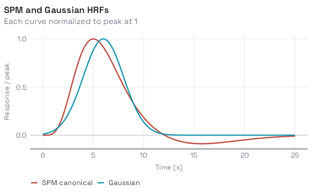

```r
time_points <- seq(0, 25, by = 0.1)

# normalize = TRUE scales each HRF to peak at 1.0
plot_hrfs(HRF_SPMG1, HRF_GAUSSIAN,
          labels = c("SPM canonical", "Gaussian"),
          normalize = TRUE,
          time = time_points,
          title = "SPM and Gaussian HRFs",
          subtitle = "Each curve normalized to peak at 1")
```

Note that the `span` attribute (e.g., 24 seconds) indicates the approximate time window over which the HRF is non-zero.

For a quick look at a single HRF, the base-graphics `plot()` method draws it and marks the peak: `plot(HRF_SPMG1)`.

## Choosing a Fixed HRF Scale

HRF scaling changes the units of fitted coefficients, so use an explicit convention when comparing designs across software. `hrf_norm = "spm"` matches the Nilearn/SPM reference-grid convention; `"unit_peak"` sets the canonical peak to one, and `"unit_integral"` sets its continuous integral to one.

```r
spm_scaled <- gen_hrf(HRF_SPMG1, hrf_norm = "spm")
spm_grid <- seq(0, 32, length.out = 1600)
sum(spm_scaled(spm_grid))
```

```
#> [1] 1
```

Use `normalize_hrf()` to scale an existing HRF object. For SPM derivative bases, the modes above apply one canonical-derived factor to every column and therefore preserve their relative scale. The legacy `normalise_hrf()` function instead gives every basis column its own unit peak.

## Modifying HRF Parameters with `gen_hrf`

The `gen_hrf` function is a flexible way to create new HRF functions, often by modifying the parameters of existing ones.

For example, the `hrf_gaussian` function takes `mean` and `sd` arguments. We can use `gen_hrf` to create Gaussian HRFs with different peak times (`mean`) and widths (`sd`).

```r
# Create Gaussian HRFs with different parameters using gen_hrf
# Note: hrf_gaussian is the underlying function, not the HRF object HRF_GAUSSIAN
hrf_gauss_4_1 <- gen_hrf(hrf_gaussian, mean = 4, sd = 1, name = "Gaussian (Mean=4, SD=1)")
hrf_gauss_5_2 <- gen_hrf(hrf_gaussian, mean = 5, sd = 2, name = "Gaussian (Mean=5, SD=2)")
hrf_gauss_7_3 <- gen_hrf(hrf_gaussian, mean = 7, sd = 3, name = "Gaussian (Mean=7, SD=3)")
```

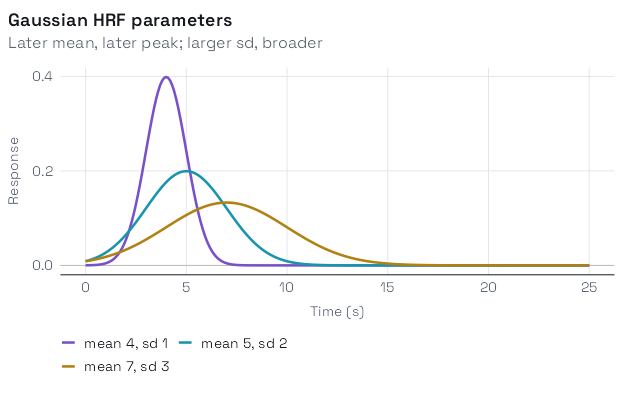

```r
plot_hrfs(hrf_gauss_4_1, hrf_gauss_5_2, hrf_gauss_7_3,
          labels = c("mean 4, sd 1", "mean 5, sd 2", "mean 7, sd 3"),
          time = time_points, palette = "ordered",
          title = "Gaussian HRF parameters",
          subtitle = "Later mean, later peak; larger sd, broader")
```

`gen_hrf` can also directly incorporate lags and durations (see later sections).

## Modeling Event Duration with `block_hrf`

fMRI events often have a duration (e.g., a stimulus presented for several seconds). The `block_hrf` function (or `gen_hrf` with a `width` argument) modifies an HRF to model the response to a sustained event of a specific `width` (duration). Internally, it convolves the original HRF with a boxcar function of the specified width.

The `precision` argument controls the sampling resolution used for this convolution.

```r
# Create blocked HRFs using the SPM canonical HRF with different durations
hrf_spm_w1 <- block_hrf(HRF_SPMG1, width = 1)
hrf_spm_w2 <- block_hrf(HRF_SPMG1, width = 2)
hrf_spm_w4 <- block_hrf(HRF_SPMG1, width = 4)
```

The three durations below and in the next sections use the ordered palette: violet is the shortest event and ochre the longest.

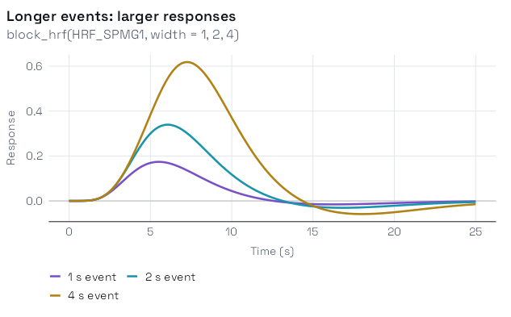

```r
plot_hrfs(hrf_spm_w1, hrf_spm_w2, hrf_spm_w4,
          labels = c("1 s event", "2 s event", "4 s event"),
          time = time_points, palette = "ordered",
          title = "Longer events: larger responses",
          subtitle = "block_hrf(HRF_SPMG1, width = 1, 2, 4)")
```

### Normalization

By default, longer durations lead to higher peak responses (assuming summation, see next section). Setting `normalize=TRUE` in `block_hrf` (or `gen_hrf`) rescales the response so the peak amplitude is 1, regardless of duration. What remains is the change in shape: longer events rise later and stay up longer.

```r
# Create normalized blocked HRFs
hrf_spm_w1_norm <- block_hrf(HRF_SPMG1, width = 1, normalize = TRUE)
hrf_spm_w2_norm <- block_hrf(HRF_SPMG1, width = 2, normalize = TRUE)
hrf_spm_w4_norm <- block_hrf(HRF_SPMG1, width = 4, normalize = TRUE)
```

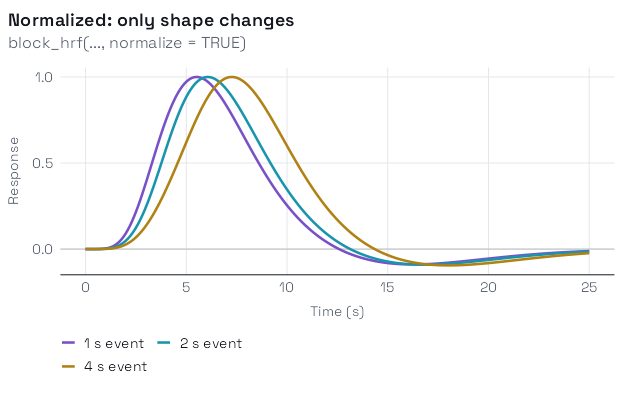

```r
plot_hrfs(hrf_spm_w1_norm, hrf_spm_w2_norm, hrf_spm_w4_norm,
          labels = c("1 s event", "2 s event", "4 s event"),
          time = time_points, palette = "ordered",
          title = "Normalized: only shape changes",
          subtitle = "block_hrf(..., normalize = TRUE)")
```

### Averaging instead of summing: `summate`

The `summate` argument in `block_hrf` controls how the response to a sustained event is built. With `summate = TRUE` (the default) the responses to each moment of the event add up, so longer events give larger peaks. With `summate = FALSE` they are averaged instead: the result is the summated response divided by the event width. The peak no longer grows with duration; for long events it falls, because the same response is spread over a longer time.

```r
# Create non-summating blocked HRFs
hrf_spm_w2_nosum <- block_hrf(HRF_SPMG1, width = 2, summate = FALSE)
hrf_spm_w4_nosum <- block_hrf(HRF_SPMG1, width = 4, summate = FALSE)
hrf_spm_w8_nosum <- block_hrf(HRF_SPMG1, width = 8, summate = FALSE)
```

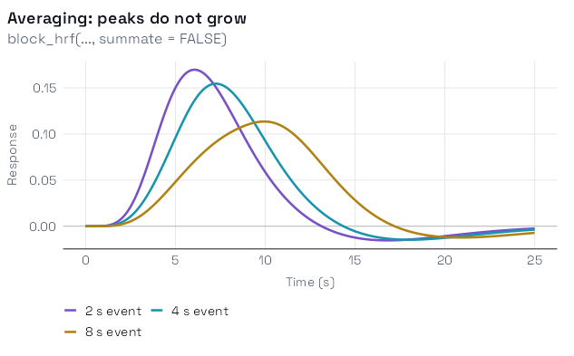

```r
plot_hrfs(hrf_spm_w2_nosum, hrf_spm_w4_nosum, hrf_spm_w8_nosum,
          labels = c("2 s event", "4 s event", "8 s event"),
          time = time_points, palette = "ordered",
          title = "Averaging: peaks do not grow",
          subtitle = "block_hrf(..., summate = FALSE)")
```

`summate = FALSE` and `normalize = TRUE` can be combined; with a unit peak, only the shape differences shown in the normalized figure above remain.

## Modeling Temporal Shifts with `lag_hrf`

Sometimes, the hemodynamic response might be delayed or advanced relative to the event onset. The `lag_hrf` function (or `gen_hrf_lagged`) shifts an existing HRF in time by a specified `lag` (in seconds). A positive lag delays the response, while a negative lag advances it.

```r
# Create lagged versions of the Gaussian HRF
hrf_gauss_lag_neg2 <- lag_hrf(HRF_GAUSSIAN, lag = -2)
hrf_gauss_lag_0 <- HRF_GAUSSIAN # Original (lag=0)
hrf_gauss_lag_pos3 <- lag_hrf(HRF_GAUSSIAN, lag = 3)
```

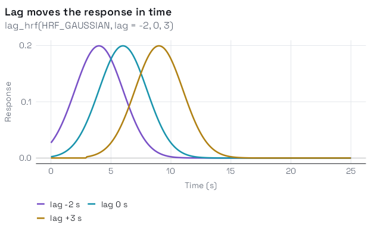

```r
plot_hrfs(hrf_gauss_lag_neg2, hrf_gauss_lag_0, hrf_gauss_lag_pos3,
          labels = c("lag -2 s", "lag 0 s", "lag +3 s"),
          time = time_points, palette = "ordered",
          title = "Lag moves the response in time",
          subtitle = "lag_hrf(HRF_GAUSSIAN, lag = -2, 0, 3)")
```

## Combining Lag and Duration

We can combine `lag_hrf` and `block_hrf` using the pipe operator (`%>%`) from `dplyr` (or `magrittr`).

```r
# Create HRFs that are both lagged and blocked
hrf_lb_1 <- HRF_GAUSSIAN %>% lag_hrf(1) %>% block_hrf(width = 1, normalize = TRUE)
hrf_lb_3 <- HRF_GAUSSIAN %>% lag_hrf(3) %>% block_hrf(width = 3, normalize = TRUE)
hrf_lb_5 <- HRF_GAUSSIAN %>% lag_hrf(5) %>% block_hrf(width = 5, normalize = TRUE)
```

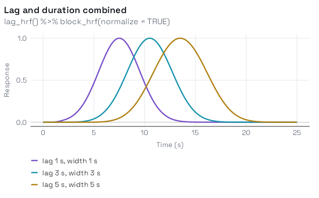

```r
plot_hrfs(hrf_lb_1, hrf_lb_3, hrf_lb_5,
          labels = c("lag 1 s, width 1 s", "lag 3 s, width 3 s", "lag 5 s, width 5 s"),
          time = time_points, palette = "ordered",
          title = "Lag and duration combined",
          subtitle = "lag_hrf() %>% block_hrf(normalize = TRUE)")
```

Alternatively, `gen_hrf` can apply lag and width directly, and gives the same function:

```r
hrf_lb_gen_3 <- gen_hrf(hrf_gaussian, lag = 3, width = 3, normalize = TRUE)

# Largest difference from the piped version over 0-25 s
max(abs(hrf_lb_gen_3(time_points) - hrf_lb_3(time_points)))
```

```
#> [1] 0.0004053635
```

## Multivariate HRFs: Basis Sets

Instead of assuming a fixed HRF shape, we can model the response using a linear combination of multiple basis functions. This allows for more flexibility in capturing variations in HRF shape across brain regions or individuals. The resulting HRF function returns a matrix where each column corresponds to a basis function, and `plot_hrfs()` draws one curve per column.

### SPM Basis Sets

`fmrihrf` provides pre-defined HRF objects for the SPM canonical HRF plus its temporal derivative (`HRF_SPMG2`), and additionally its dispersion derivative (`HRF_SPMG3`).

```r
# SPM + Temporal Derivative (2 basis functions)
print(HRF_SPMG2)
```

```
#> -- HRF: SPMG2 ---------------------------------------------
#>    Basis functions: 2
#>    Span: 24 s
```

```r
# SPM + Temporal + Dispersion Derivatives (3 basis functions)
print(HRF_SPMG3)
```

```
#> -- HRF: SPMG3 ---------------------------------------------
#>    Basis functions: 3
#>    Span: 24 s
```

`HRF_SPMG2` is the first two columns of `HRF_SPMG3`, so one figure shows both:

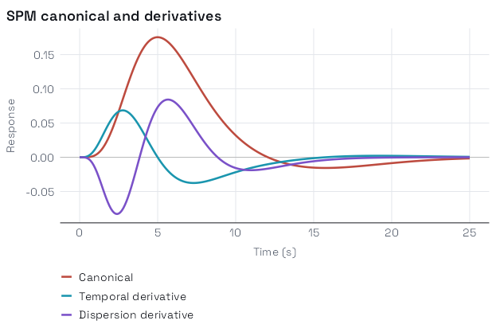

```r
plot_hrfs(HRF_SPMG3,
          labels = c("Canonical", "Temporal derivative", "Dispersion derivative"),
          time = time_points,
          title = "SPM canonical and derivatives")
```

Why the temporal derivative? Adding a small multiple of it to the canonical HRF shifts the peak in time. This is how a GLM with `HRF_SPMG2` absorbs small latency differences:

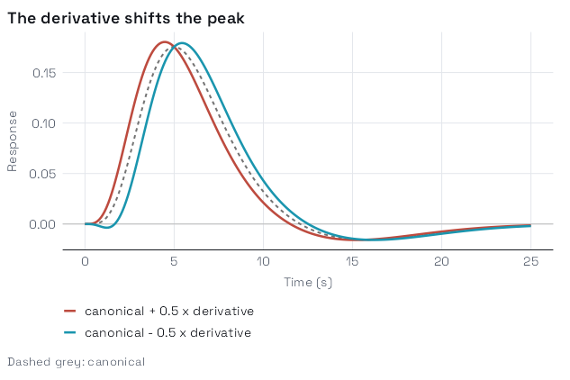

```r
spm_early <- gen_empirical_hrf(time_points,
  drop(HRF_SPMG2(time_points) %*% c(1, 0.5)))
spm_late <- gen_empirical_hrf(time_points,
  drop(HRF_SPMG2(time_points) %*% c(1, -0.5)))

plot_hrfs(spm_early, spm_late,
          labels = c("canonical + 0.5 x derivative", "canonical - 0.5 x derivative"),
          time = time_points, reference = HRF_SPMG1, reference_label = "canonical",
          title = "The derivative shifts the peak")
```

### B-Spline Basis Set

The `hrf_bspline` function generates a B-spline basis set. We typically use it within `gen_hrf` to create an HRF object. Key parameters are `N` (number of basis functions) and `degree`.

```r
# B-spline basis with N=5 basis functions, degree=3 (cubic)
hrf_bs_5_3 <- gen_hrf(hrf_bspline, N = 5, degree = 3, name = "B-spline (N=5, deg=3)")
print(hrf_bs_5_3)
```

```
#> -- HRF: B-spline (N=5, deg=3) -----------------------------
#>    Basis functions: 5
#>    Span: 24 s
```

```r
# B-spline basis with N=11 basis functions, degree=1 (linear -> tent functions):
# tents peak every 2 s, at 2, 4, ..., 22 s
hrf_bs_10_1 <- gen_hrf(hrf_bspline, N = 11, degree = 1, name = "Tent Set (N=11)")
print(hrf_bs_10_1)
```

```
#> -- HRF: Tent Set (N=11) -----------------------------------
#>    Basis functions: 11
#>    Span: 24 s
```

Each basis function covers a different stretch of the 24-second window; their weighted sum can take almost any smooth shape. Every function is zero at 0 s and at 24 s, so any weighted combination starts and ends at baseline.

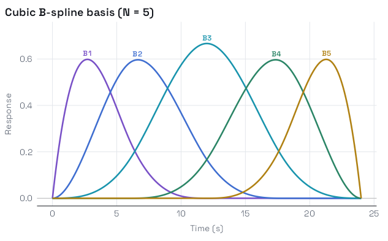

```r
bspline_times <- seq(0, 24, by = 0.1)
plot_hrfs(hrf_bs_5_3, time = bspline_times,
          title = "Cubic B-spline basis (N = 5)")
```

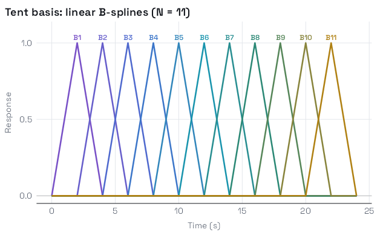

```r
plot_hrfs(hrf_bs_10_1, time = bspline_times,
          title = "Tent basis: linear B-splines (N = 11)")
```

### Sine Basis Set

The `hrf_sine` function creates a basis set using sine waves of different frequencies. Overlaid, five sine waves are hard to read, so each gets its own panel:

```r
hrf_sin_5 <- gen_hrf(hrf_sine, N = 5, name = "Sine Basis (N=5)")
print(hrf_sin_5)
```

```
#> -- HRF: Sine Basis (N=5) ----------------------------------
#>    Basis functions: 5
#>    Span: 24 s
```

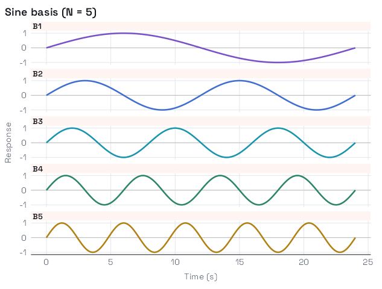

```r
plot_hrfs(hrf_sin_5, time = bspline_times, layout = "stack",
          title = "Sine basis (N = 5)")
```

### Half-Cosine Basis Set (FLOBS-like)

The `hrf_half_cosine` function implements the half-cosine HRF described by Woolrich et al. (2004), the model behind FSL’s FLOBS (FMRIB’s Linear Optimal Basis Sets). Four half-cosine segments of durations `h1`–`h4` model the initial dip, rise, fall, and recovery; `f1` and `f2` set the height of the initial dip and the undershoot. The defaults set both to zero, giving a single bump; negative values add the dip and undershoot:

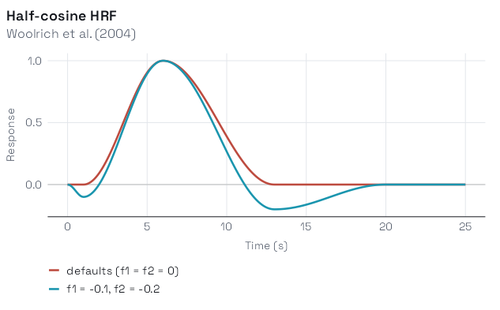

```r
hrf_hc_default <- gen_hrf(hrf_half_cosine, name = "Half-cosine (default)")
hrf_hc_dip <- gen_hrf(hrf_half_cosine, f1 = -0.1, f2 = -0.2,
                      name = "Half-cosine (f1 = -0.1, f2 = -0.2)")
plot_hrfs(hrf_hc_default, hrf_hc_dip,
          labels = c("defaults (f1 = f2 = 0)", "f1 = -0.1, f2 = -0.2"),
          time = time_points,
          title = "Half-cosine HRF",
          subtitle = "Woolrich et al. (2004)")
```

## Other HRF Shapes

`fmrihrf` has several other parametric shapes. Each is created with `gen_hrf()`:

```r
# Gamma probability density
hrf_gam <- gen_hrf(hrf_gamma, shape = 6, rate = 1, name = "Gamma (shape=6, rate=1)")

# Mexican hat wavelet (second derivative of a Gaussian)
hrf_mh <- gen_hrf(hrf_mexhat, mean = 6, sd = 1.5, name = "Mexican Hat (mean=6, sd=1.5)")

# Difference of two inverse-logit (sigmoid) functions: separate rise and fall
hrf_il <- gen_hrf(hrf_inv_logit, mu1 = 5, s1 = 1, mu2 = 15, s2 = 1.5, name = "Inv. Logit Diff.")
```

The gamma peaks at `(shape - 1) / rate` = 5 s; the Mexican hat has negative lobes on both sides of its peak; the inverse-logit difference rises around `mu1` and falls around `mu2`, giving a plateau:

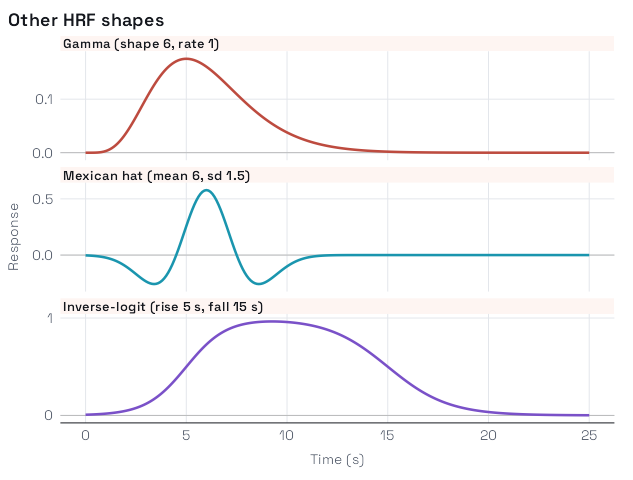

```r
plot_hrfs(hrf_gam, hrf_mh, hrf_il,
          labels = c("Gamma (shape 6, rate 1)", "Mexican hat (mean 6, sd 1.5)",
                     "Inverse-logit (rise 5 s, fall 15 s)"),
          time = time_points, layout = "stack",
          title = "Other HRF shapes")
```

## Boxcar and Weighted HRFs (No Hemodynamic Delay)

Traditional HRFs model the hemodynamic delay—the sluggish blood flow response that peaks several seconds after neural activity. However, sometimes you want to extract signal from specific time windows *without* assuming any hemodynamic transformation. This is useful for:

- Extracting raw signal averages from specific post-stimulus windows
- Trial-wise analyses where you want the mean (or weighted mean) of the BOLD signal
- Comparing signal in different temporal windows directly
- Creating custom temporal weighting schemes

### Simple Boxcar HRF (`hrf_boxcar`)

The `hrf_boxcar` function creates a simple step function that is constant within a time window and zero outside. Unlike traditional HRFs, there is no built-in hemodynamic delay—the HRF starts at time 0 (event onset) and extends for the specified `width`.

```r
# Create a boxcar of width 5 seconds (from 0 to 5 seconds)
hrf_box <- hrf_boxcar(width = 5)
print(hrf_box)
```

```
#> -- HRF: boxcar[5] -----------------------------------------
#>    Basis functions: 1
#>    Span: 5 s
#>    Parameters: width = 5, amplitude = 1, normalize = FALSE
```

To create a boxcar that starts at a later time point—useful for capturing signal in a specific post-stimulus window—use `lag_hrf()`:

```r
# Boxcar from 4-8 seconds post-stimulus (capturing the expected BOLD peak)
# Use lag_hrf() to delay a 4-second boxcar by 4 seconds
hrf_delayed <- hrf_boxcar(width = 4) %>% lag_hrf(lag = 4)
```

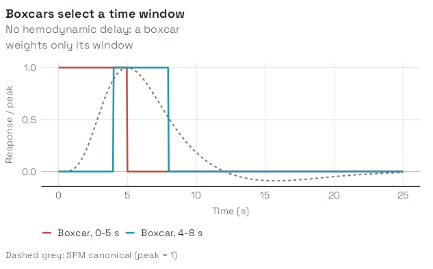

```r
plot_hrfs(hrf_box, hrf_delayed,
          labels = c("Boxcar, 0-5 s", "Boxcar, 4-8 s"),
          normalize = TRUE, time = seq(0, 25, by = 0.05),
          reference = HRF_SPMG1, reference_label = "SPM canonical (peak = 1)",
          title = "Boxcars select a time window",
          subtitle = "No hemodynamic delay: a boxcar weights only its window")
```

### What β Estimates: Boxcar Height

The height of a boxcar sets the units of its regression coefficient. With the default amplitude of 1, an isolated event’s β estimates the **mean** signal in the window. With `normalize = TRUE`, the boxcar is scaled to unit area (height `1/width`), so β estimates the **integrated** signal over the window: the mean multiplied by the window width.

```r
# Unit-area boxcar: a 4-second window lagged by 4 seconds (4-8 s)
hrf_norm <- hrf_boxcar(width = 4, normalize = TRUE) %>% lag_hrf(lag = 4)

# Check: amplitude should be 1/4 = 0.25
t_fine <- seq(0, 12, by = 0.01)
resp_norm <- evaluate(hrf_norm, t_fine)
cat("Amplitude of normalized boxcar:", max(resp_norm), "\n")
```

```
#> Amplitude of normalized boxcar: 0.25
```

```r
cat("Expected (1/width):", 1/4, "\n")
```

```
#> Expected (1/width): 0.25
```

```r
# Verify integral ≈ 1
integral <- sum(resp_norm) * 0.01
cat("Integral of normalized boxcar:", round(integral, 3), "\n")
```

```
#> Integral of normalized boxcar: 1
```

A quick least-squares check with a signal of 5 inside the 4-8 s window:

```r
scan_t <- seq(0, 40, by = 0.5)
y <- ifelse(scan_t >= 4 & scan_t < 8, 5, 0)
beta <- function(hrf) {
  x <- evaluate(regressor(0, hrf), scan_t)
  unname(coef(lm(y ~ x))["x"])
}
c(height_1 = beta(hrf_boxcar(width = 4) %>% lag_hrf(lag = 4)),  # about 5: the mean
  unit_area = beta(hrf_norm))                                   # about 20: 5 x 4 s
```

```
#>  height_1 unit_area
#>  4.861713 19.446853
```

Use the default height when you want β in signal units (the window mean); use `normalize = TRUE` when you want the window’s integrated response.

### Weighted HRF (`hrf_weighted`)

The `hrf_weighted` function provides more flexibility by allowing you to specify different weights at different time points. You can either:

- Use `width` + `weights`: evenly space the weights across the specified width
- Use `times` + `weights`: explicitly specify the time points for each weight

This creates either a step function (`method = "constant"`) or a smoothly interpolated function (`method = "linear"`). With `method = "constant"`, each weight fills one time bin: with `width`, the window is split into equal bins; with `times`, weight *i* runs from `times[i]` to `times[i + 1]`, and the last bin is as wide as the one before it.

```r
# 6 weights over a 10-second window: six equal bins of 10/6 s
hrf_wt_width <- hrf_weighted(
  weights = c(0.1, 0.3, 1.0, 1.0, 0.3, 0.1),
  width = 10,
  method = "constant"
)

# The same weights in 2-second bins starting at 2, 4, ..., 12 s (window 2-14 s)
hrf_wt <- hrf_weighted(
  weights = c(0.1, 0.3, 1.0, 1.0, 0.3, 0.1),
  times = c(2, 4, 6, 8, 10, 12),
  method = "constant"
)

# Smooth weights using linear interpolation between the same time points
hrf_smooth <- hrf_weighted(
  weights = c(0.1, 0.3, 1.0, 1.0, 0.3, 0.1),
  times = c(2, 4, 6, 8, 10, 12),
  method = "linear"
)
```

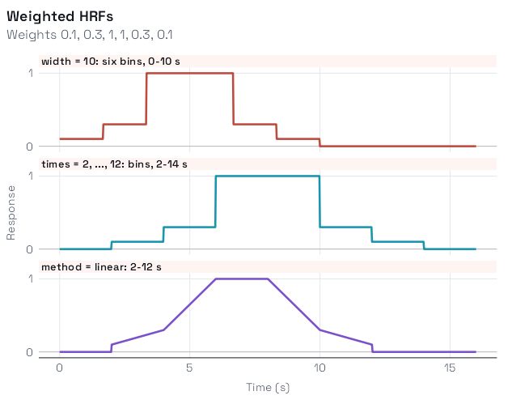

```r
plot_hrfs(hrf_wt_width, hrf_wt, hrf_smooth,
          labels = c("width = 10: six bins, 0-10 s",
                     "times = 2, ..., 12: bins, 2-14 s",
                     "method = linear: 2-12 s"),
          time = seq(0, 16, by = 0.02), layout = "stack",
          title = "Weighted HRFs", subtitle = "Weights 0.1, 0.3, 1, 1, 0.3, 0.1")
```

#### Sub-second Precision

The `hrf_weighted` function supports sub-second time intervals, which is useful for fine-grained temporal weighting:

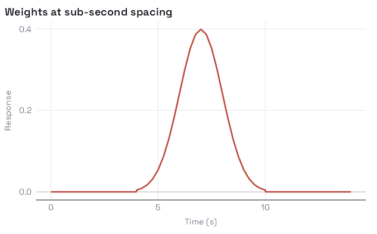

```r
# Sub-second intervals: create a Gaussian-shaped weight function
times_fine <- seq(4, 10, by = 0.25)
weights_gaussian <- dnorm(times_fine, mean = 7, sd = 1)

hrf_gauss_wt <- hrf_weighted(weights_gaussian, times = times_fine, method = "linear")

plot_hrfs(hrf_gauss_wt, labels = "Gaussian weights, 0.25 s spacing",
          time = seq(0, 14, by = 0.02),
          title = "Weights at sub-second spacing")
```

### Normalized Weighted HRF

When `normalize = TRUE`, the weights are scaled to sum to 1 (`method = "constant"`) or the curve to integrate to 1 (`method = "linear"`). This fixes the scale of the weighting profile, which makes coefficients comparable across profiles. It does not turn β into a weighted mean: least squares fits the amplitude of the whole profile, β = Σ w(t) y(t) / Σ w(t)², which equals a plain mean only for a boxcar. To summarise a window as a weighted mean, compute that mean directly from the data.

```r
hrf_wt_norm <- hrf_weighted(
  weights = c(1, 2, 2, 1),  # Will be normalized
  times = c(4, 6, 8, 10),
  method = "constant",
  normalize = TRUE
)

# Four 2-second bins (4-6, 6-8, 8-10, 10-12 s); weights 1, 2, 2, 1 are
# rescaled to 1/6, 2/6, 2/6, 1/6
evaluate(hrf_wt_norm, c(5, 7, 9, 11, 13))
```

```
#> [1] 0.1666667 0.3333333 0.3333333 0.1666667 0.0000000
```

### Practical Example: Comparing Early vs. Late Response Windows

A common analysis compares BOLD signal in early vs. late portions of a trial. Here’s how to set up HRFs for this:

```r
# Early window: 2-6 seconds (4-second boxcar lagged by 2 seconds)
hrf_early <- hrf_boxcar(width = 4) %>% lag_hrf(lag = 2)

# Late window: 8-12 seconds (4-second boxcar lagged by 8 seconds)
hrf_late <- hrf_boxcar(width = 4) %>% lag_hrf(lag = 8)
```

These boxcars have height 1, so each β is the mean signal in its window. Drawn against the canonical response (scaled to the same height), the early window covers the rise and peak, and the late window the return to baseline:

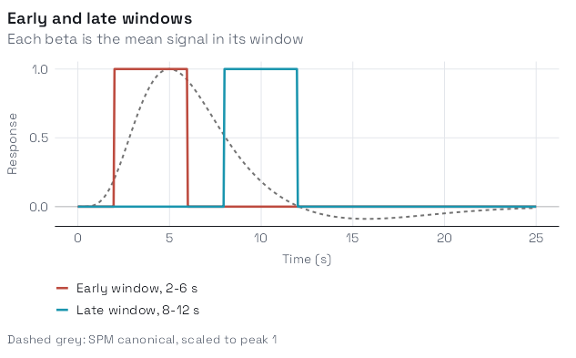

```r
spm_ref <- gen_empirical_hrf(time_points,
  HRF_SPMG1(time_points) / max(HRF_SPMG1(time_points)))
plot_hrfs(hrf_early, hrf_late,
          labels = c("Early window, 2-6 s", "Late window, 8-12 s"),
          time = seq(0, 25, by = 0.05),
          reference = spm_ref, reference_label = "SPM canonical, scaled to peak 1",
          title = "Early and late windows",
          subtitle = "Each beta is the mean signal in its window")
```

Using these HRFs in separate regressors allows you to estimate and compare the mean BOLD signal in each window.

### Using Boxcar/Weighted HRFs with Regressors

These HRFs integrate seamlessly with the `regressor()` function:

```r
# Create a regressor with boxcar HRF (4-second window starting 4s after onset)
reg_boxcar <- regressor(
  onsets = c(0, 20, 40),
  hrf = hrf_boxcar(width = 4, normalize = TRUE) %>% lag_hrf(lag = 4)
)

# Compare with traditional SPM HRF
reg_spm <- regressor(onsets = c(0, 20, 40), hrf = HRF_SPMG1)
```

The two regressors have different units, so each gets its own panel (and y axis). Grey bars under each panel mark the event onsets. The small notches at 24 and 44 s are where the previous event’s canonical response is cut off at the end of its 24-second span (see the regressor vignette):

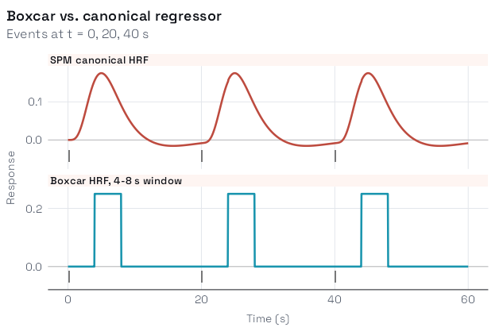

```r
plot_regressors(reg_spm, reg_boxcar,
                labels = c("SPM canonical HRF", "Boxcar HRF, 4-8 s window"),
                grid = seq(0, 60, by = 0.05), layout = "stack",
                title = "Boxcar vs. canonical regressor",
                subtitle = "Events at t = 0, 20, 40 s")
```

## Creating Custom Basis Sets with `hrf_set`

The `hrf_set` function allows you to combine *any* set of HRF functions into a single multivariate HRF object (a basis set).

For example, we can create a basis set from a series of lagged Gaussian HRFs:

```r
# Create a list of lagged Gaussian HRFs
lag_times <- seq(0, 10, by = 2)
list_of_hrfs <- lapply(lag_times, function(lag) {
  lag_hrf(HRF_GAUSSIAN, lag = lag)
})

# Combine them into a single HRF basis set object
hrf_custom_set <- do.call(hrf_set, list_of_hrfs)
print(hrf_custom_set) # Note: name is default 'hrf_set', nbasis is 6
```

```
#> -- HRF: hrf_set -------------------------------------------
#>    Basis functions: 6
#>    Span: 34 s
```

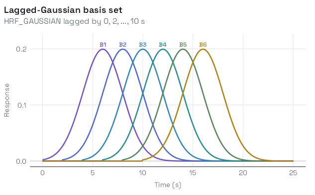

```r
plot_hrfs(hrf_custom_set, time = time_points,
          title = "Lagged-Gaussian basis set",
          subtitle = "HRF_GAUSSIAN lagged by 0, 2, ..., 10 s")
```

## Creating Empirical HRFs

### From a Single Measured Response (`gen_empirical_hrf`)

If you have a measured or estimated hemodynamic response profile (e.g., from deconvolution), you can turn it into an HRF function using `gen_empirical_hrf`. It uses linear interpolation between the provided points.

```r
# Simulate an average measured response profile
sim_times <- 0:24
set.seed(42) # For reproducibility
sim_profile <- rowMeans(replicate(20, {
  h <- HRF_SPMG1 %>% lag_hrf(lag = runif(n = 1, min = -1, max = 1)) %>%
                    block_hrf(width = runif(n = 1, min = 0, max = 2))
  h(sim_times)
}))

# Normalize profile to max = 1 for better visualization
sim_profile_norm <- sim_profile / max(sim_profile)

# Create the empirical HRF function from the normalized profile
emp_hrf <- gen_empirical_hrf(sim_times, sim_profile_norm)
print(emp_hrf)
```

```
#> -- HRF: empirical_hrf -------------------------------------
#>    Basis functions: 1
#>    Span: 24 s
```

The points are the measured profile; the line is the interpolating HRF:

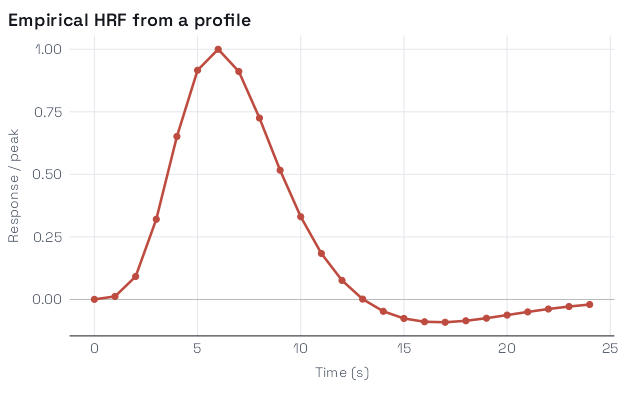

### Empirical Basis Set via PCA

You can create an empirical *basis set* by applying dimensionality reduction (like PCA) to a collection of observed or simulated HRFs.

```r
# 1. Simulate a matrix of diverse HRFs
set.seed(123) # for reproducibility
n_sim <- 50
sim_mat <- replicate(n_sim, {
  hrf_func <- HRF_SPMG1 %>%
              lag_hrf(lag = runif(1, -2, 2)) %>%
              block_hrf(width = runif(1, 0, 3))
  hrf_func(sim_times)
})
```

The 50 simulated responses vary in latency and width; PCA finds the few shapes that capture most of this variation:

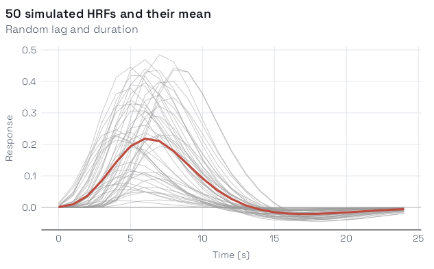

```r
# 2. Perform PCA on the transpose (each column = one HRF, each row = one time point)
pca_res <- prcomp(t(sim_mat), center = TRUE, scale. = FALSE)
n_components <- 3

# Print variance explained by top components
variance_explained <- summary(pca_res)$importance[2, 1:n_components]
cat("Variance explained by top", n_components, "components:",
    paste0(round(variance_explained * 100, 1), "%"), "\n")
```

```
#> Variance explained by top 3 components: 67.3% 30% 2.5%
```

```r
# Extract the top principal components
pc_vectors <- pca_res$rotation[, 1:n_components]

# 3. Convert principal components into HRF functions
list_pc_hrfs <- list()

for (i in 1:n_components) {
  pc_vec <- pc_vectors[, i]
  # The sign of a principal component is arbitrary; make its largest
  # deviation positive so PC1 looks like an HRF rather than its mirror image
  pc_vec <- pc_vec * sign(pc_vec[which.max(abs(pc_vec - pc_vec[1]))] - pc_vec[1])
  pc_vec_zeroed <- pc_vec - pc_vec[1]
  max_abs <- max(abs(pc_vec_zeroed))
  pc_vec_norm <- pc_vec_zeroed / max_abs
  list_pc_hrfs[[i]] <- gen_empirical_hrf(sim_times, pc_vec_norm)
}

# 4. Combine PC HRFs into a basis set using hrf_set
emp_pca_basis <- do.call(hrf_set, list_pc_hrfs)
print(emp_pca_basis)
```

```
#> -- HRF: hrf_set -------------------------------------------
#>    Basis functions: 3
#>    Span: 24 s
```

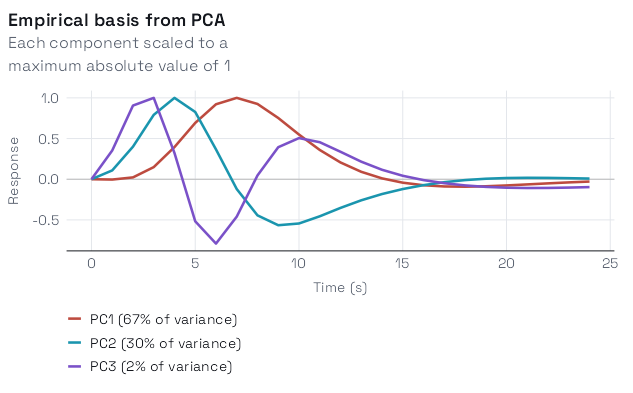

```r
plot_hrfs(emp_pca_basis,
          labels = paste0("PC", 1:n_components, " (",
                          round(variance_explained * 100), "% of variance)"),
          time = seq(0, 24, by = 0.1),
          title = "Empirical basis from PCA",
          subtitle = "Each component scaled to a maximum absolute value of 1")
```

This empirical basis set can then be used in regression models just like any other pre-defined or custom basis set.